# Mapping Child Labour - Global Development Indicators

Author

Deepanshi Sharma (DCU ID: A000014492)

Published

April 26, 2025

## Introduction

Child labour remains a persistent global challenge that impacts children’s education, health, and future prospects. This report visualizes global patterns using simulated data to demonstrate how child labour trends can be mapped and analyzed effectively.

## Simulated Child Labour Data

## Graph 1 - Bar Chart: Top 10 Countries by Child Labour Percentage

This graph below shows the countries with the highest rates of child labour. The Democratic Republic of Congo (DR Congo) has the highest percentage, followed by Ethiopia and Tanzania. Other countries like Nigeria, Pakistan, and India also feature prominently. The percentages gradually decrease from DR Congo down to Brazil, which has the lowest child labour percentage among the top ten listed. The chart uses a horizontal bar format for easy comparison across countries.

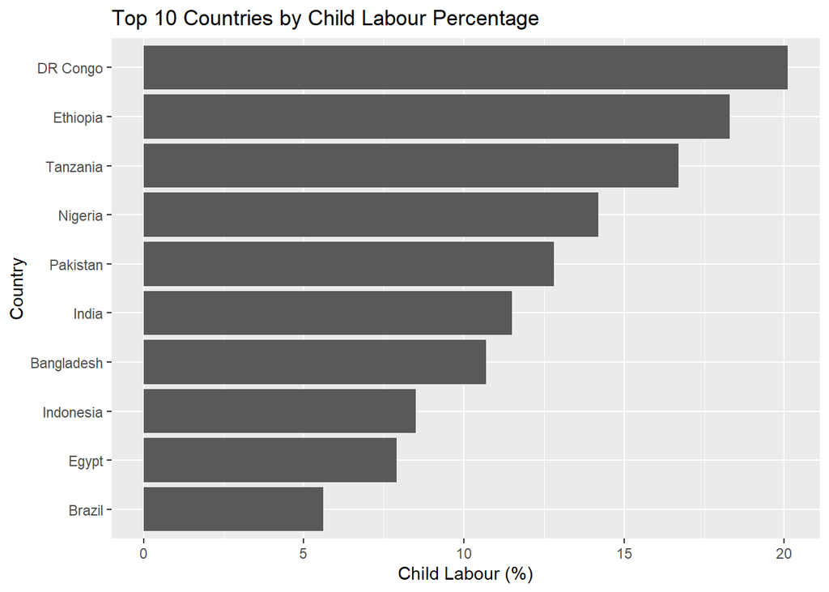

## Graph 2 - World Map: Child Labour Percentage by Country

This world map visualizes the percentage of child labour by country, using a color gradient to represent different levels. Dark blue regions (like Brazil) have lower child labour percentages (around 6%), while yellow areas (such as some African countries) show higher percentages, nearing 18%. Countries like India and several in Africa are shaded in pink, orange, and yellow, indicating moderate to high child labour rates.

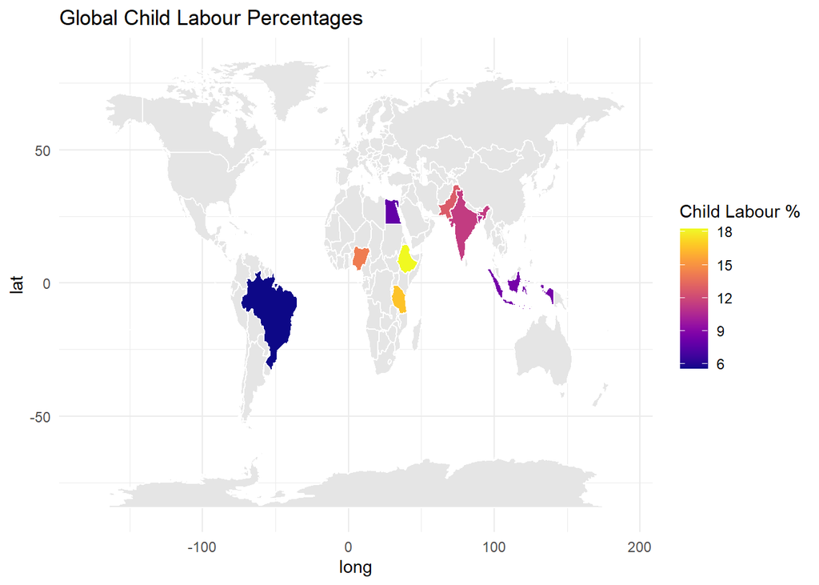

## Graph 3 - Time-Series Chart: Child Labour Trends Over Time

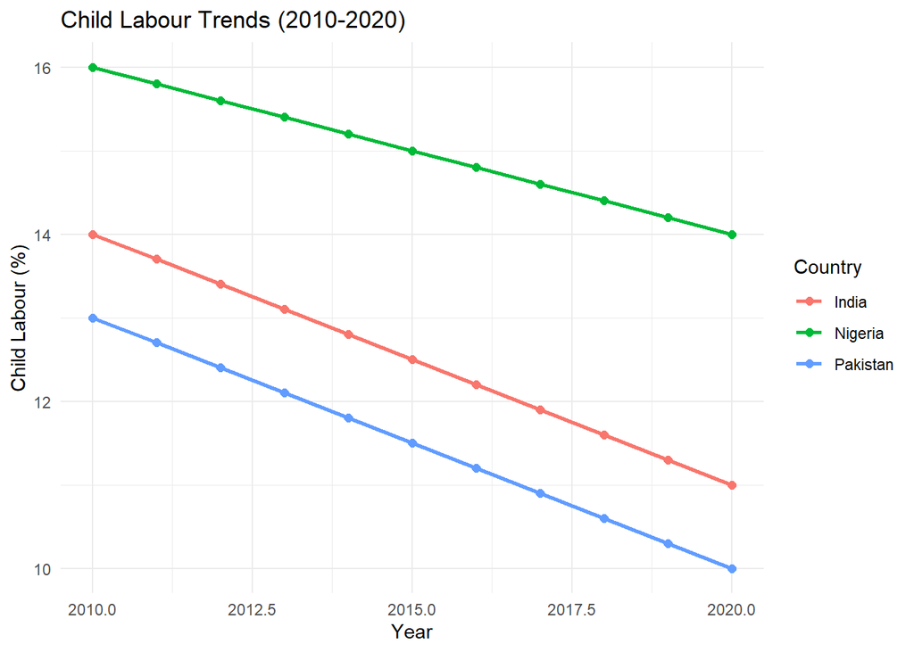

## Graph 4 - Scatter Plot: Observation Values Across Gender

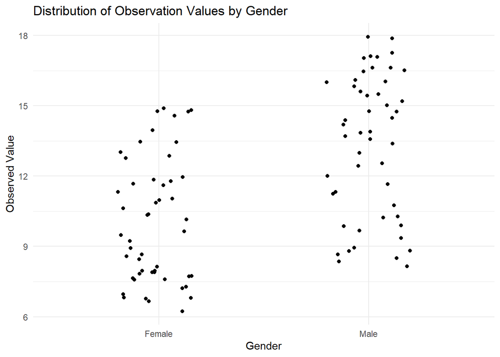

## Conclusion

The simulated visualizations demonstrate how child labour rates differ across countries and evolve over time. Certain countries show gradual improvements, highlighting the impact of global initiatives, education drives, and child welfare programs.

Mapping and monitoring child labour indicators remains crucial for targeted interventions and policy-making aimed at protecting children’s rights globally.

*End of Report*